# Digital and Algorithmic Marketing: Homework 2

# Recommendation Systems

### Jorge Adrian Sánchez

With the ‘reccomendarlab’ package from R, we have two datasets: the first, cointains 1,664 movies and all the general information about these movies; the second, is a matrix of 943 people that have reated this 1,664 movies. Note that not all the people rated all the movies. So, as we can see in the following image, rows are users that might or not rate a particular movie (columns) in blank(or white). The “scale-color” is the rating per movie.

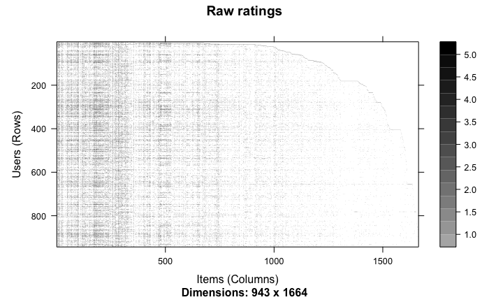

## Question 1

#### Use the MovieLense dataset to compare the performance of user based (UBCF) and item based (IBCF) collaborative filtering models.

##### a) Split the data into training and holdout samples [use 80/20 split (train/holdout) for the first 900 users in MovieLense database].

In this case 80% of 900 represents 720 users which will be our train dataset and our test dataset (holdout) will be represented by 180 users.

```r
## create 80/20 split (known/unknown) for the first 900 users in dataset
e <- evaluationScheme(MovieLense[1:900], method="split", train=0.8,k=1, given=15, goodRating=4)
e
```

```
Evaluation scheme with 15 items given
Method: ‘split’ with 1 run(s).
Training set proportion: 0.800
Good ratings: >=4.000000
Data set: 900 x 1664 rating matrix of class ‘realRatingMatrix’ with 95515 ratings.
```

#### b) Compare the time it takes to fit the UBCF and IBCF models.

We can evaluate the methods by taking the time it takes to train the recommendation with the system.time() function form R

```r
## create a user-based CF recommender using training data
system.time(r_ubcf <- Recommender(getData(e, "train"), "UBCF"))
```

```
   user  system elapsed
  0.011   0.001   0.013
```

```r
system.time(r_ibcf <- Recommender(getData(e, "train"), "IBCF"))
```

```
   user  system elapsed
 31.563   5.468  35.544
```

#### c) Predict the entire unknown ratings for the users in the holdout data using the fitted UBCF and IBCF models. Compare the predictive accuracy and the time it takes to make the predictions.

#### Prediction

For the prediction based on the UBCF the output is a realRatingMatrix in which each column is a movie title, and the rows are the 180 user with rating values for each movie. We can see the first 20 users and their first 100 ratings

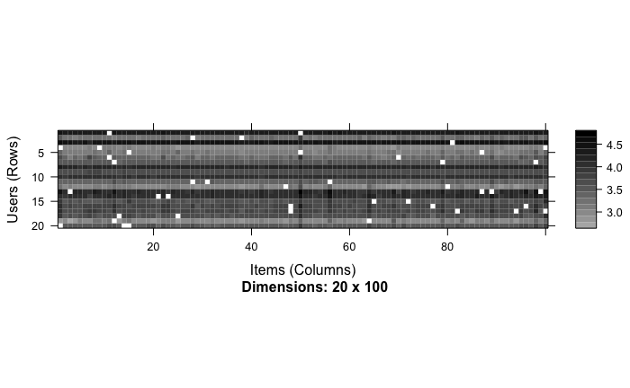

The same for the Item Based Collaborative Filtering

```r
## create predictions for the test data using known ratings (see given above)
system.time(prediction_ibcf <- predict(r_ibcf, getData(e, "known"), type="ratings"))
```

```
   user  system elapsed
  0.041   0.012   0.053
```

```r
prediction_ibcf
```

```
180 x 1664 rating matrix of class ‘realRatingMatrix’ with 36214 ratings.
```

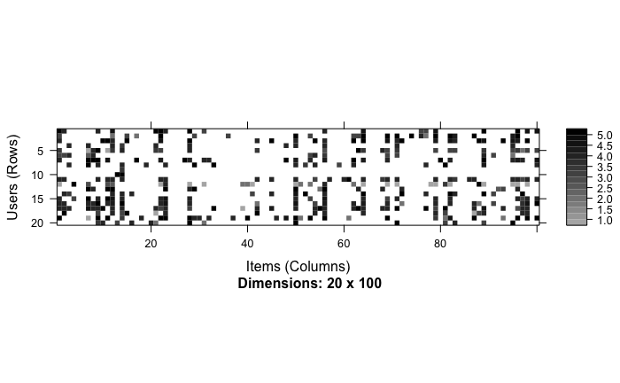

#### A. Root mean square error (RMSE)

#### UBCF

```
     RMSE       MSE       MAE
1.0758714 1.1574993 0.8634688
```

#### IBCF

```
     RMSE       MSE       MAE
1.2494122 1.5610308 0.9121275
```

In this comparison, we could see that the **root mean square error (RMSE)** is less in the **User Based Collaborative Filtering** than in the Item Based Collaborative Filtering.

### EVALUATING top-N recommendations

Also, we can use the `evaluate` function in which we can obtain the ROC curve to see how well which model is more accurate when predicting a top-N list. In this case we have:

```r
#meta-parameters of the models
algorithms <- list(`user-based CF` = list(name = "UBCF", param = list(method = "Cosine", nn = 50)),
                   `item-based CF` = list(name = "IBCF", param = list(method = "Cosine", k = 50)))
scheme <- evaluationScheme(MovieLense[1:900], method = "split", train = .8, k = 1, given = 10, goodRating = 4)
#n= number of recommendations
evaluation_results <- evaluate(scheme, algorithms,type = "topNList", n=c(3,5,10,20))
```

```
UBCF run fold/sample [model time/prediction time]
     1  [0.008sec/1.744sec]
IBCF run fold/sample [model time/prediction time]
     1  [36.358sec/0.108sec]
```

```r
evaluation_results
```

```
List of evaluation results for 2 recommenders:
Evaluation results for 1 folds/samples using method ‘UBCF’.
Evaluation results for 1 folds/samples using method ‘IBCF’.
```

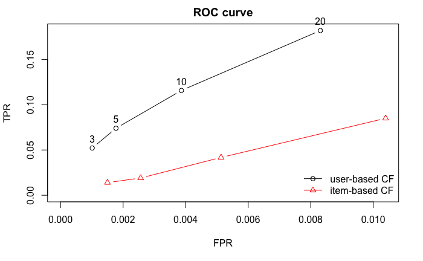

We can see that the recommendation time it takes to fit the UBCF and IBCF models is similar compare to the ratings. UBCF time < IBCF time.

#### B. Confusion Matrix

The confusion matrix of our evaluation results for ‘UBCF’:

```
Evaluation results for 1 folds/samples using method ‘UBCF’.
         TP        FP       FN       TN precision     recall        TPR         FPR
3  1.344444  1.638889 50.18889 1600.828 0.4506518 0.05217342 0.05217342 0.001013161
5  2.105556  2.866667 49.42778 1599.600 0.4234637 0.07397951 0.07397951 0.001772043
10 3.700000  6.244444 47.83333 1596.222 0.3720670 0.11572595 0.11572595 0.003863661
20 6.466667 13.422222 45.06667 1589.044 0.3251397 0.18187833 0.18187833 0.008308388
```

The confusion matrix of our evaluation results for ‘IBCF’:

```
Evaluation results for 1 folds/samples using method ‘IBCF’.
          TP        FP       FN       TN precision     recall        TPR         FPR
3  0.5722222  2.411111 50.96111 1600.056 0.1918063 0.01394436 0.01394436 0.001499725
5  0.8555556  4.116667 50.67778 1598.350 0.1720670 0.01904818 0.01904818 0.002560576
10 1.6944444  8.250000 49.83889 1594.217 0.1703911 0.04173230 0.04173230 0.005132078
20 3.1833333 16.705556 48.35000 1585.761 0.1600559 0.08498161 0.08498161 0.010395659
```

### C. Comparing Overlap of top-N recommender algorithms

For checking the overlap, I used a Out-Sample without crossvalidation and a Top-N list prediction model for the Top-100 movie recomendation.

```r
train <- MovieLense[1:900]
test <- MovieLense[900:943]
# Training the recommender
r1 <- Recommender(train, method = "UBCF")
r2 <- Recommender(train, method = "IBCF")
# Predict for the test data
rec1 = predict(r1,test,n=100)
rec2 = predict(r2,test,n=100)
```

So depending on the number of your top-N reccomendation range, in this case we want to give a Top-List of 100, we would like to know how our first model and second model overlaps for each user top-N reccomendation

```r
overlap = c()
for (x in 1:43){
  c<- rec.overlap(rec1,rec2,i=x)
  overlap = c(overlap, c)
}
```

WE can see that generally, our two algorithms agrees on around 19 movies in general per reccomendation:

```r
summary(overlap)
```

```
   Min. 1st Qu.  Median    Mean 3rd Qu.    Max.
   3.00   14.00   19.00   19.35   22.50   44.00
```

**We can combine both algorithms and have a general recommendation for a specific user based on this information.**

#### Q2: Imagine that you could append movie characteristics (Budget, Genre, Studio, Actors, Director etc.) to this data. How would you use this to construct a recommendation system? Outline any specifics you can about this new system.

We can use this data as features to measure the simmilarity between the movies. In this case we just have simillarity based on ratings, but we can add more features to compute our distance metric based on more dimensions. In this case, budget, genre, studio, actors, director etc. could have an impact to rate movies based on its similarities in all the dimensions and not just the rating.